# re_stepwise

Simon Rüegg

2025-04-14

# Report exercise

## Loading packages

```r
library(ggplot2)
library(dplyr)
```

## Read in half-hourly fluxes data

```r
half_hourly_fluxes <- read.csv("../data/df_for_stepwise_regression.csv")
```

## Evaluating all bivariate models with a single predictor

```r
# define GPP and the predictors
gpp <- half_hourly_fluxes$GPP_NT_VUT_REF
predictors <- half_hourly_fluxes %>% select(-siteid, -TIMESTAMP) |>
  tidyr::drop_na()#delete location, time stamp and GPP from the half hourly fluxes dataframe an drop na values
```

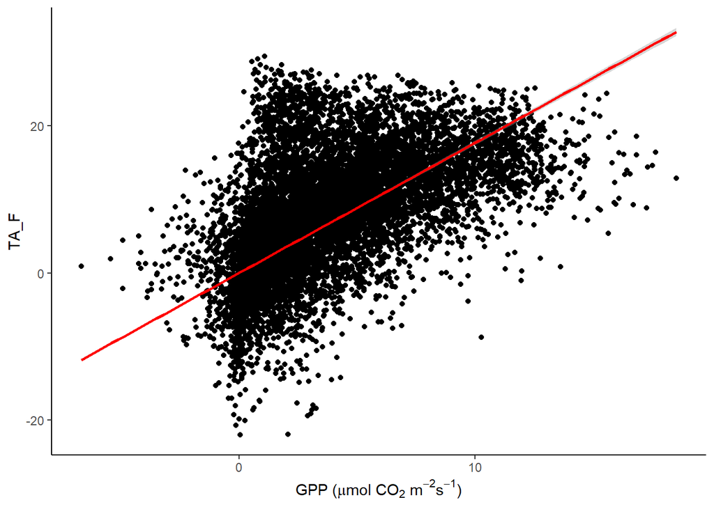

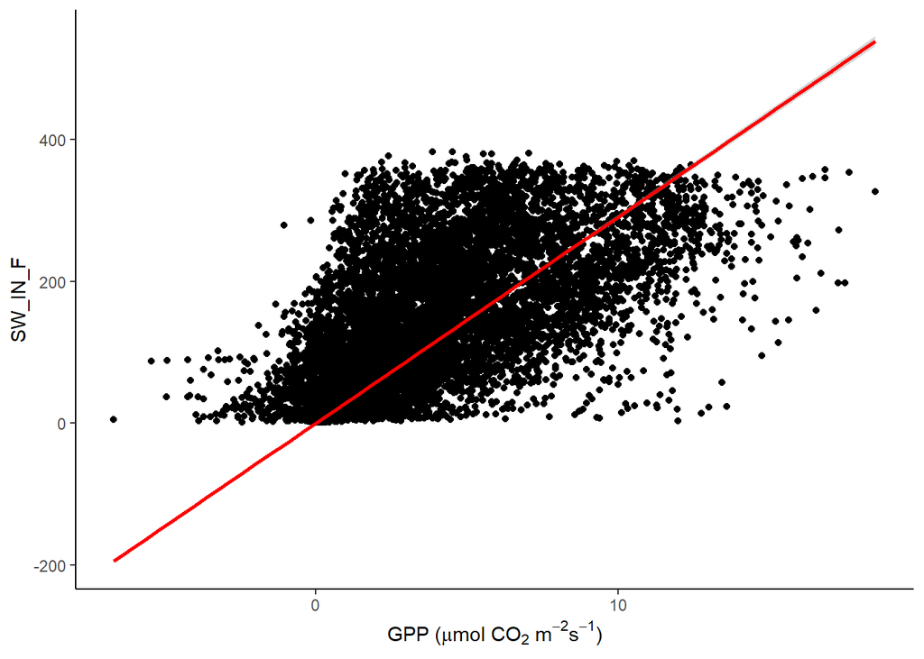

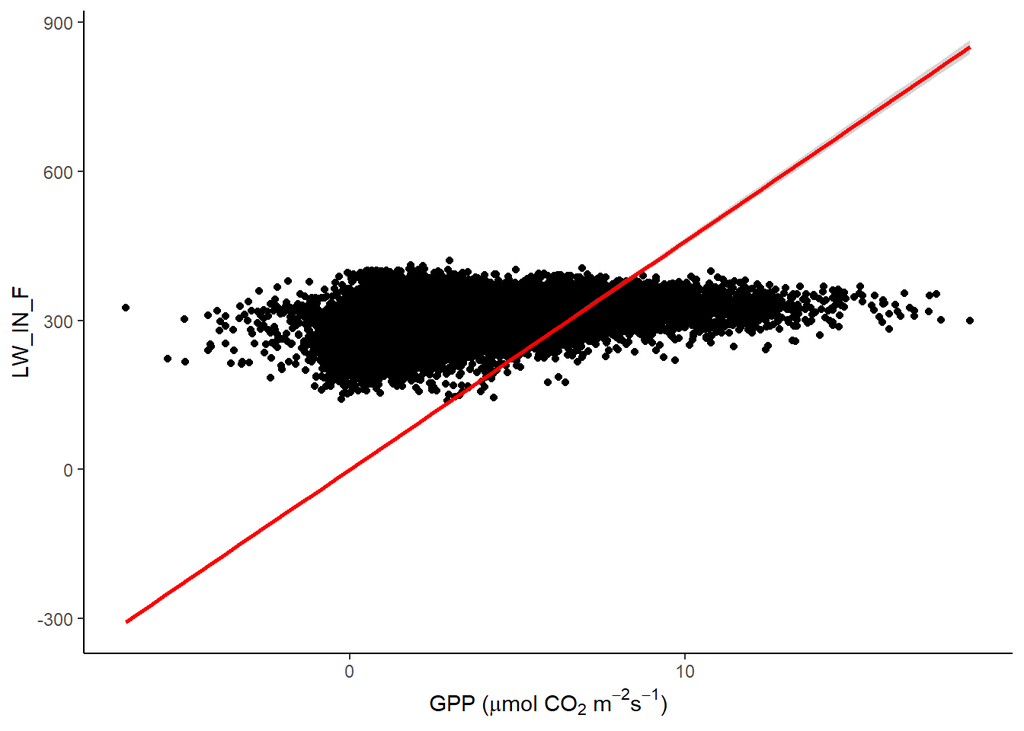

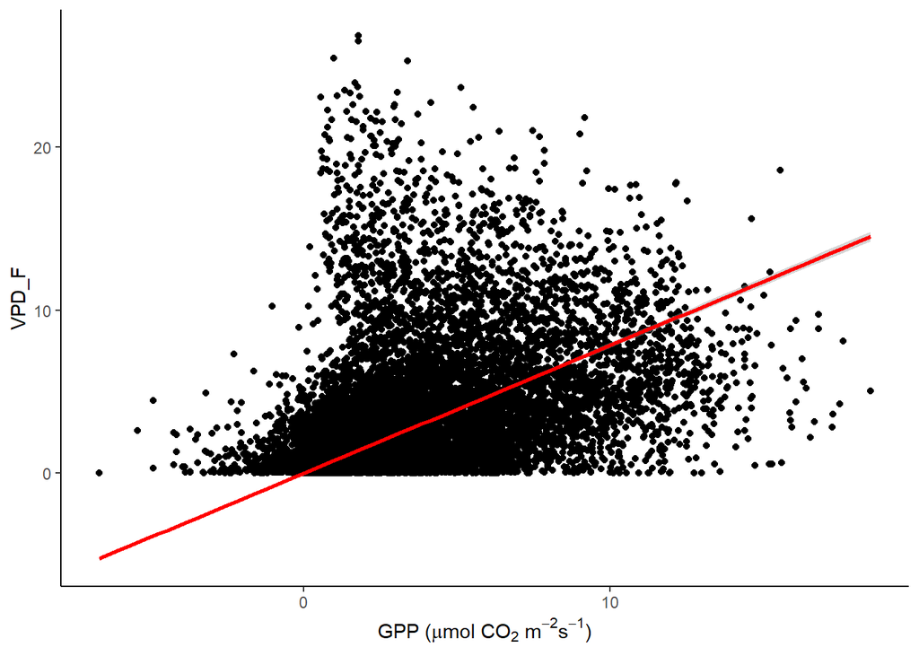

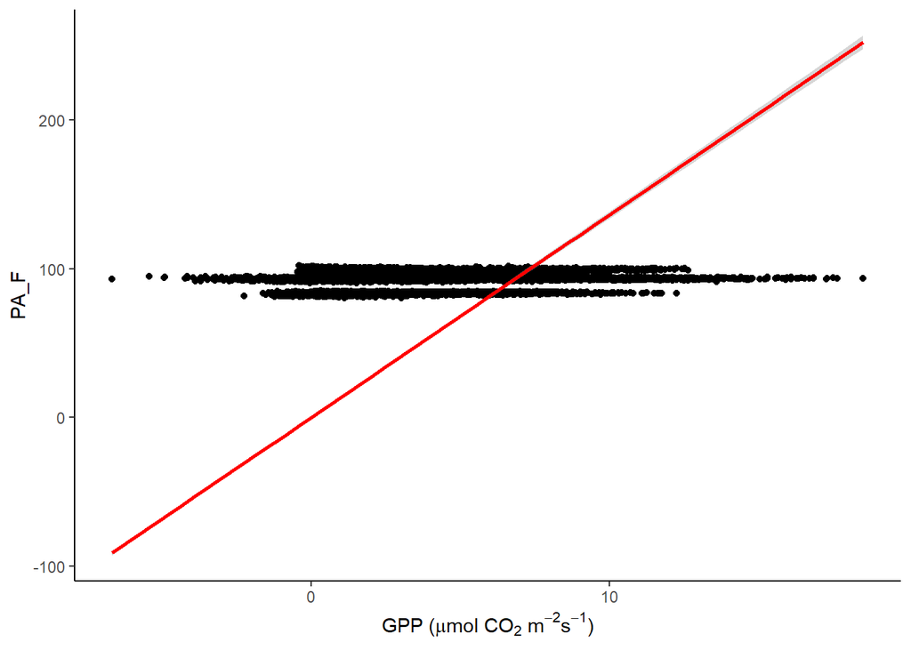

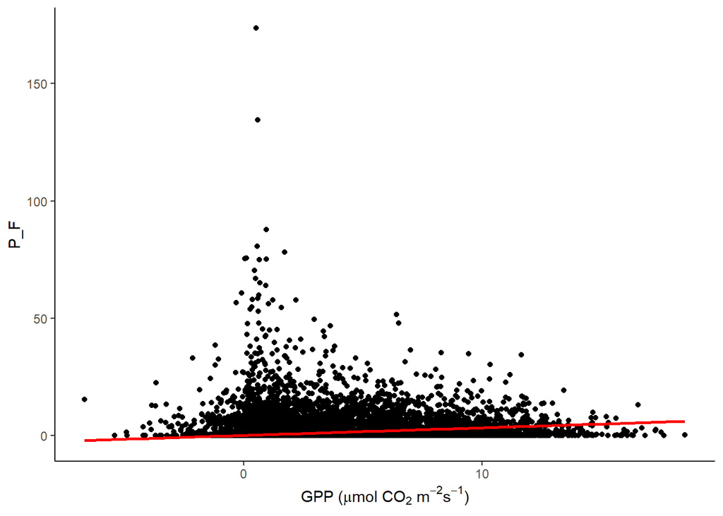

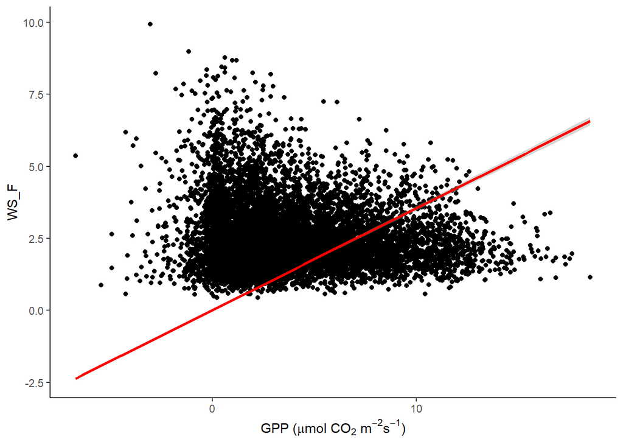

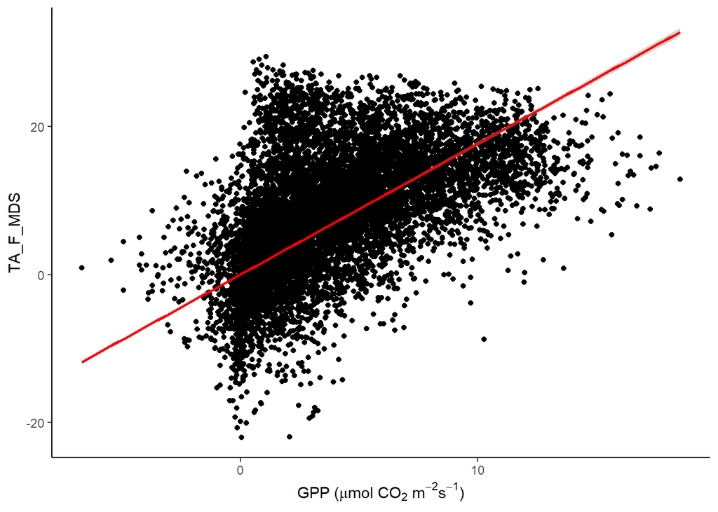

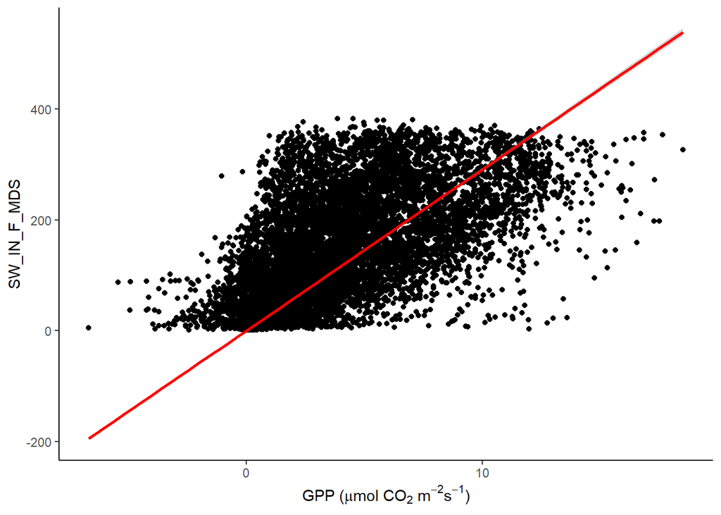

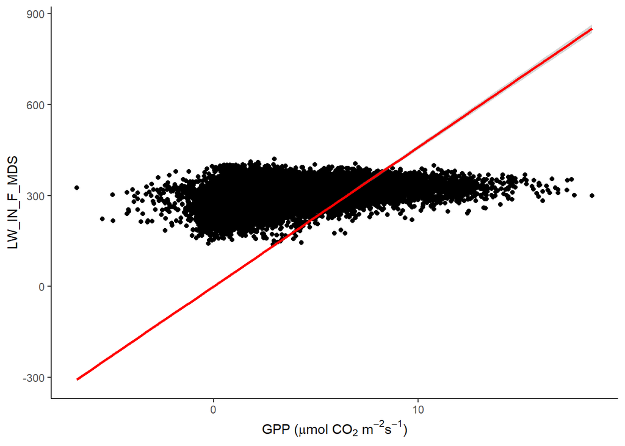

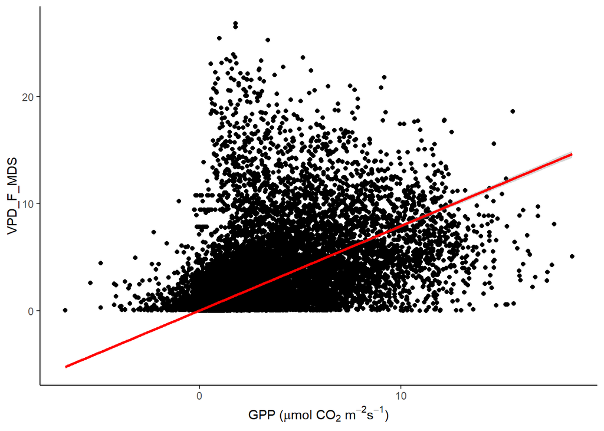

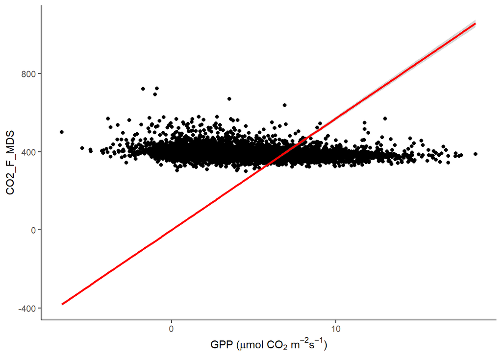

[2 more figures not shown]

```r
# do steps 1-3 to get the predictor with the highest R^2
name_predictors <- names(predictors)
r_squared_max <- 0
index_pred_max <- c()

#find column in predictors with highest R^2
i_r_squared_max <- 0
for (i in 1:length(predictors)) {
  if (i != 14) {
    string_pred <- paste("GPP_NT_VUT_REF ~ ", paste(name_predictors[i])) #string with to calculate lm
    string_pred <- formula(string_pred) # delete the "" in the string
    linmod <- lm(string_pred, data = predictors)
    r_squared <- summary(linmod)$r.squared

    # memorise heighest R^2
    if (r_squared > r_squared_max) {
      r_squared_max <- r_squared #safe value of the heighest R^2
      index_pred_max <- i #safes the index of the column where the heighst index is (in predictors)
    }

    # Making plots for the different predictors
    print(predictors |>
            ggplot(aes(x = predictors$GPP_NT_VUT_REF, y = predictors[, i])) +
                   geom_point() +
                     geom_smooth(formula = y ~ x +0, method = lm, color = "red") +
                     labs(x = expression(paste("GPP (", mu,"mol CO"[2], " m"^-2, "s"^-1, ")")), y = name_predictors[i]) +
                     theme_classic())

  }
}
```

As we did search for the heighst R^2 we found it. The heighst R^2 is

```r
name_r_squared <- names(predictors[index_pred_max])
```

“name_r_squared” safes the name of the column with the heighst R^2. In this case it is “PPFD_IN”. The value of R^2 between the GPP and the PPFD_IN is safed in “r_squared_max”. This value is around 0.4527.

```r
# Compute the AIC of the heighst R^2

# calculating the sse and the n fpr the AIC
sse <- sum((predictors[, index_pred_max] - mean(predictors[, index_pred_max]))^2)
n <- length(predictors[, index_pred_max])
p <- 1

AIC <- n * log(sse/n) + 2 * (p + 2)
```

## Stepwise forward regression

```r
# form loop for the stepwise forward regression
name_predictors <- names(predictors)
r_squared_max <- 0
index_pred_max <- 0
used_pred_max <- c()
count_predictors <- 0
start <- 1

while (start == 1) {
  for (i in 1:length(predictors)) {
    if (i != 14 & !(i %in% used_pred_max)){ #for-loop do not take GPP or already used predictors
      string_pred <- paste("GPP_NT_VUT_REF ~ ", paste(name_predictors[i])) #string with to calculate lm
      string_pred <- formula(string_pred) #delete the "" in the string
      linmod <- lm(string_pred, data = predictors)
      r_squared <- summary(linmod)$r.squared

      # memorise heighest R^2
      if (r_squared > r_squared_max) {
        r_squared_max <- r_squared #safe value of the highest R^2
        index_pred_max <- i #safes index of the highest R^2 somehow that does not work
      }
    }
  }
  start <- 0 #stops while loop to add index of maximum R^2 to the used_pred_max vector
  used_pred_max <- c(used_pred_max, index_pred_max) #index of the added predictor gets added in vector used_pred_max
  r_squared_max <- 0 # sets squared max to 0 for new loop

  # calculate AIC
  sse <- c()
  pot_col <- c(used_pred_max, index_pred_max)
  subset_predictors <- predictors[, pot_col]

  for (j in 1:length(names(subset_predictors))) {
    sse[j] <- sum((subset_predictors[, j] - mean(subset_predictors[, j]))^2)
  }
  sse_2 <- sum(sse)
  num_var <- length(predictors[, 1]) * length(used_pred_max)

  aic_value <- num_var * log(sse_2/num_var) + 2 * (length(used_pred_max) + 2)

  if (AIC < aic_value) {
    start <- 0
  }
  else {
    used_pred_max <- c(used_pred_max, index_pred_max)
  }
}
```

## Visualize the results

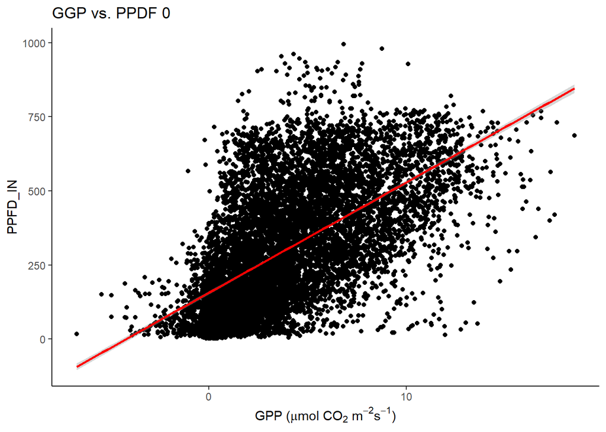

```r
r_value <- round(r_squared_max, 5)

ggplot(data = predictors, aes(x = GPP_NT_VUT_REF, y = PPFD_IN, )) +
  geom_point() +
  geom_smooth(formula = y ~ x, method = "lm", color = "red", fullrange = T,
    aes(x = predictors$GPP_NT_VUT_REF, y = predictors$PPFD_IN)) +
  ggtitle(paste("GGP vs. PPDF", r_value)) +
  labs(x = expression(paste("GPP (", mu,"mol CO"[2], " m"^-2, "s"^-1, ")")), y = "PPFD_IN") +
  theme_classic()
```

The visualization I got here shows a scatterplot between the GPP and the PPFD. Sadly I was not able to complete the loop the determine which predictors have influence to the GPP. My code does not loop another predictor and just takes the best one for the first run, which is the PPFD. The code should check for the highest R^2 after the determination of the already used variables. And then determine the aic_value of the used predictors and the new one. As soon as the new aic_value is not smaller then the previous aic_value we have all the variable which have an influence or are highly connected with the GPP. The gaol is to find a model which can make the best prediction of the GPP.